# Homework 12

Kevin Bui

2024-02-29

## Instructions

Answer the following questions and complete the exercises in RMarkdown. Please embed all of your code and push your final work to your repository. Your final lab report should be organized, clean, and run free from errors. Remember, you must remove the `#` for the included code chunks to run. Be sure to add your name to the author header above. For any included plots, make sure they are clearly labeled. You are free to use any plot type that you feel best communicates the results of your analysis.

Make sure to use the formatting conventions of RMarkdown to make your report neat and clean!

## Load the libraries

```r
library(tidyverse)
library(janitor)
#install.packages("ggmap")
library(ggmap)
```

```r
#register_stadiamaps("a307e07a-2fe4-4da6-ba93-18d754418e5b", write = FALSE)
```

## Load the Data

We will use two separate data sets for this homework.

1. The first [data set](https://rcweb.dartmouth.edu/~f002d69/workshops/index_rspatial.html) represent sightings of grizzly bears (Ursos arctos) in Alaska.

```r
grizzly <- read.csv("data/bear-sightings.csv")
```

2. The second data set is from Brandell, Ellen E (2021), Serological dataset and R code for: Patterns and processes of pathogen exposure in gray wolves across North America, Dryad, [Dataset](https://doi.org/10.5061/dryad.5hqbzkh51).

```r
wolves <- read_csv("data/wolves_data/wolves_dataset.csv")
```

1. Load the `grizzly` data and evaluate its structure.

```r
grizzly
```

```
##     bear.id longitude latitude
## 1         7 -148.9560 62.65822
## 2        57 -152.6228 58.35064
## 3        69 -144.9374 62.38227
## 4        75 -152.8485 59.90122
## 5       104 -143.2948 61.07311
## 6       108 -149.7111 62.91605
## 7       115 -151.8361 67.98965
## 8       116 -147.4335 62.55425
## 9       125 -157.3959 60.21360
## 10      135 -155.7483 58.86458
## 11      137 -144.2276 67.17227
## 12      162 -162.7296 55.01637
## 13      185 -133.7962 56.86191
## 14      208 -145.5893 64.65146
```

[output cut: 480 more lines]

```r
str(grizzly)
```

```
## 'data.frame':    494 obs. of  3 variables:
##  $ bear.id  : int  7 57 69 75 104 108 115 116 125 135 ...
##  $ longitude: num  -149 -153 -145 -153 -143 ...
##  $ latitude : num  62.7 58.4 62.4 59.9 61.1 ...
```

2. Use the range of the latitude and longitude to build an appropriate bounding box for your map.

```r
grizzly %>%
  select(longitude, latitude) %>%
  summary()
```

```
##    longitude         latitude
##  Min.   :-166.2   Min.   :55.02
##  1st Qu.:-154.2   1st Qu.:58.13
##  Median :-151.0   Median :60.97
##  Mean   :-149.1   Mean   :61.41
##  3rd Qu.:-145.6   3rd Qu.:64.13
##  Max.   :-131.3   Max.   :70.37
```

```r
long <- c(-166.2, -131.3)
lat <- c(55.02, 70.37)
bbox <- make_bbox(long, lat, f = .05)
```

3. Load a map from `stamen` in a terrain style projection and display the map.

```r
map <- get_stadiamap(bbox, maptype = "stamen_terrain", zoom = 5)
```

```
## ℹ © Stadia Maps © Stamen Design © OpenMapTiles © OpenStreetMap contributors.
```

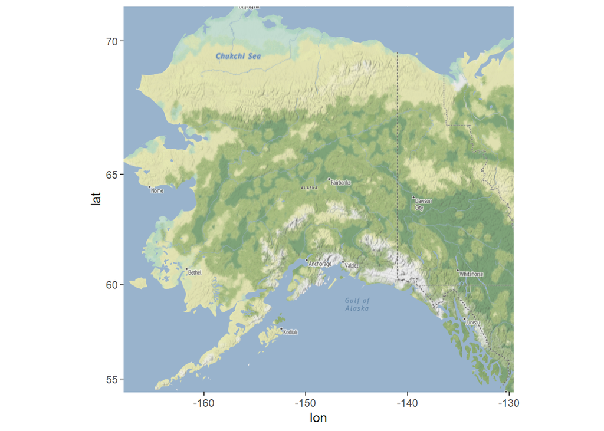

```r
ggmap(map)
```

4. Build a final map that overlays the recorded observations of grizzly bears in Alaska.

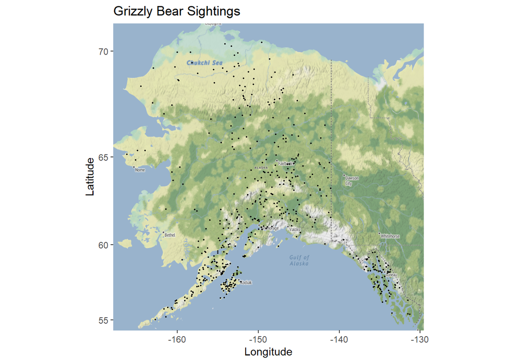

```r
ggmap(map) + geom_point(data = grizzly, aes(longitude, latitude), size = .4) + labs(title = "Grizzly Bear Sightings", x = "Longitude", y = "Latitude")
```

Let’s switch to the wolves data. Brandell, Ellen E (2021), Serological dataset and R code for: Patterns and processes of pathogen exposure in gray wolves across North America, Dryad, [Dataset](https://doi.org/10.5061/dryad.5hqbzkh51).

5. Load the data and evaluate its structure.

```r
wolves
```

```
## # A tibble: 1,986 × 23
##    pop     year age.cat sex   color   lat  long habitat human pop.density
##    <chr>  <dbl> <chr>   <chr> <chr> <dbl> <dbl>   <dbl> <dbl>       <dbl>
##  1 AK.PEN  2006 S       F     G      57.0 -158.    254.  10.4           8
##  2 AK.PEN  2006 S       M     G      57.0 -158.    254.  10.4           8
##  3 AK.PEN  2006 A       F     G      57.0 -158.    254.  10.4           8
##  4 AK.PEN  2006 S       M     B      57.0 -158.    254.  10.4           8
##  5 AK.PEN  2006 A       M     B      57.0 -158.    254.  10.4           8
##  6 AK.PEN  2006 A       M     G      57.0 -158.    254.  10.4           8
##  7 AK.PEN  2006 A       F     G      57.0 -158.    254.  10.4           8
##  8 AK.PEN  2006 P       M     G      57.0 -158.    254.  10.4           8
##  9 AK.PEN  2006 S       F     G      57.0 -158.    254.  10.4           8
## 10 AK.PEN  2006 P       M     G      57.0 -158.    254.  10.4           8
## # ℹ 1,976 more rows
## # ℹ 13 more variables: pack.size <dbl>, standard.habitat <dbl>,
## #   standard.human <dbl>, standard.pop <dbl>, standard.packsize <dbl>,
## #   standard.latitude <dbl>, standard.longitude <dbl>, cav.binary <dbl>,
## #   cdv.binary <dbl>, cpv.binary <dbl>, chv.binary <dbl>, neo.binary <dbl>,
## #   toxo.binary <dbl>
```

```r
str(wolves)
```

```
## spc_tbl_ [1,986 × 23] (S3: spec_tbl_df/tbl_df/tbl/data.frame)
##  $ pop               : chr [1:1986] "AK.PEN" "AK.PEN" "AK.PEN" "AK.PEN" ...
##  $ year              : num [1:1986] 2006 2006 2006 2006 2006 ...
##  $ age.cat           : chr [1:1986] "S" "S" "A" "S" ...
##  $ sex               : chr [1:1986] "F" "M" "F" "M" ...
##  $ color             : chr [1:1986] "G" "G" "G" "B" ...
##  $ lat               : num [1:1986] 57 57 57 57 57 ...
##  $ long              : num [1:1986] -158 -158 -158 -158 -158 ...
##  $ habitat           : num [1:1986] 254 254 254 254 254 ...
##  $ human             : num [1:1986] 10.4 10.4 10.4 10.4 10.4 ...
##  $ pop.density       : num [1:1986] 8 8 8 8 8 8 8 8 8 8 ...
##  $ pack.size         : num [1:1986] 8.78 8.78 8.78 8.78 8.78 8.78 8.78 8.78 8.78 8.78 ...
##  $ standard.habitat  : num [1:1986] -1.63 -1.63 -1.63 -1.63 -1.63 ...
##  $ standard.human    : num [1:1986] -0.978 -0.978 -0.978 -0.978 -0.978 ...
##  $ standard.pop      : num [1:1986] -0.683 -0.683 -0.683 -0.683 -0.683 ...
##  $ standard.packsize : num [1:1986] 1.32 1.32 1.32 1.32 1.32 ...
##  $ standard.latitude : num [1:1986] 0.721 0.721 0.721 0.721 0.721 ...
##  $ standard.longitude: num [1:1986] -2.14 -2.14 -2.14 -2.14 -2.14 ...
##  $ cav.binary        : num [1:1986] 1 1 1 0 1 1 1 1 1 1 ...
##  $ cdv.binary        : num [1:1986] 0 0 0 0 0 1 0 0 0 0 ...
##  $ cpv.binary        : num [1:1986] 0 0 1 1 0 1 0 0 0 0 ...
##  $ chv.binary        : num [1:1986] 1 1 1 1 1 1 1 1 1 0 ...
##  $ neo.binary        : num [1:1986] NA NA NA 0 0 NA NA 1 0 1 ...
##  $ toxo.binary       : num [1:1986] NA NA NA 1 0 NA NA 1 0 0 ...
##  - attr(*, "spec")=
##   .. cols(
##   ..   pop = col_character(),
##   ..   year = col_double(),
##   ..   age.cat = col_character(),
##   ..   sex = col_character(),
##   ..   color = col_character(),
##   ..   lat = col_double(),
##   ..   long = col_double(),
##   ..   habitat = col_double(),
##   ..   human = col_double(),
##   ..   pop.density = col_double(),
##   ..   pack.size = col_double(),
##   ..   standard.habitat = col_double(),
##   ..   standard.human = col_double(),
##   ..   standard.pop = col_double(),
##   ..   standard.packsize = col_double(),
##   ..   standard.latitude = col_double(),
##   ..   standard.longitude = col_double(),
##   ..   cav.binary = col_double(),
##   ..   cdv.binary = col_double(),
##   ..   cpv.binary = col_double(),
##   ..   chv.binary = col_double(),
##   ..   neo.binary = col_double(),
##   ..   toxo.binary = col_double()
##   .. )
##  - attr(*, "problems")=<externalptr>
```

6. How many distinct wolf populations are included in this study? Mae a new object that restricts the data to the wolf populations in the lower 48 US states.

```r
wolves %>%
  summarize(distinct = n_distinct(pop))
```

```
## # A tibble: 1 × 1
##   distinct
##      <int>
## 1       17
```

```r
tabyl(wolves, pop)
```

```
##      pop   n     percent
##   AK.PEN 100 0.050352467
##  BAN.JAS  96 0.048338369
##       BC 145 0.073011078
##   DENALI 154 0.077542800
##    ELLES  11 0.005538771
##     GTNP  60 0.030211480
##   INT.AK  35 0.017623364
##  MEXICAN 181 0.091137966
##       MI 102 0.051359517
##       MT 351 0.176737160
##    N.NWT  67 0.033736153
##      ONT  60 0.030211480
##    SE.AK  10 0.005035247
##      SNF  92 0.046324270
##   SS.NWT  34 0.017119839
##      YNP 383 0.192849950
##     YUCH 105 0.052870091
```

```r
wolves %>%
  filter(pop != "AK.PEN" & pop != "DENALI" & pop!= "INT.AK" & pop != "YUCH" & pop != "ELLES" & pop != "N.NWT" & pop!= "SS.NWT" & pop != "BC" & pop != "SE.AK" & pop != "BAN.JAS" & pop != "MEXICAN" & pop != "ONT")
```

```
## # A tibble: 988 × 23
##    pop    year age.cat sex   color   lat  long habitat human pop.density
##    <chr> <dbl> <chr>   <chr> <chr> <dbl> <dbl>   <dbl> <dbl>       <dbl>
##  1 GTNP   2012 P       M     G      43.8 -111.  10375. 3924.        34.0
##  2 GTNP   2012 P       F     G      43.8 -111.  10375. 3924.        34.0
##  3 GTNP   2012 P       F     G      43.8 -111.  10375. 3924.        34.0
##  4 GTNP   2012 P       M     B      43.8 -111.  10375. 3924.        34.0
##  5 GTNP   2013 A       F     G      43.8 -111.  10375. 3924.        34.0
##  6 GTNP   2013 A       M     G      43.8 -111.  10375. 3924.        34.0
##  7 GTNP   2013 P       M     G      43.8 -111.  10375. 3924.        34.0
##  8 GTNP   2013 P       M     G      43.8 -111.  10375. 3924.        34.0
##  9 GTNP   2013 P       M     G      43.8 -111.  10375. 3924.        34.0
## 10 GTNP   2013 P       F     G      43.8 -111.  10375. 3924.        34.0
## # ℹ 978 more rows
## # ℹ 13 more variables: pack.size <dbl>, standard.habitat <dbl>,
## #   standard.human <dbl>, standard.pop <dbl>, standard.packsize <dbl>,
## #   standard.latitude <dbl>, standard.longitude <dbl>, cav.binary <dbl>,
## #   cdv.binary <dbl>, cpv.binary <dbl>, chv.binary <dbl>, neo.binary <dbl>,
## #   toxo.binary <dbl>
```

```r
#i thought way more of these would be in america
```

7. Use the range of the latitude and longitude to build an appropriate bounding box for your map.

```r
wolves %>%
  filter(pop != "AK.PEN" & pop != "DENALI" & pop!= "INT.AK" & pop != "YUCH" & pop != "ELLES" & pop != "N.NWT" & pop!= "SS.NWT" & pop != "BC" & pop != "SE.AK" & pop != "BAN.JAS" & pop != "MEXICAN" & pop != "ONT") %>%
  select(long, lat) %>%
  summary()
```

```
##       long              lat
##  Min.   :-110.99   Min.   :43.82
##  1st Qu.:-110.99   1st Qu.:44.60
##  Median :-110.55   Median :46.15
##  Mean   :-106.49   Mean   :45.80
##  3rd Qu.:-110.55   3rd Qu.:46.83
##  Max.   : -86.82   Max.   :47.75
```

```r
long2 <- c(-110.99, -86.82)
lat2 <- c(43.82, 47.75)
bbox2 <- make_bbox(long2, lat2, f = .05)
```

8. Load a map from `stamen` in a `terrain-lines` projection and display the map.

```r
map2 <- get_stadiamap(bbox2, maptype = "stamen_terrain_lines", zoom = 5)
```

```
## ℹ © Stadia Maps © Stamen Design © OpenMapTiles © OpenStreetMap contributors.
```

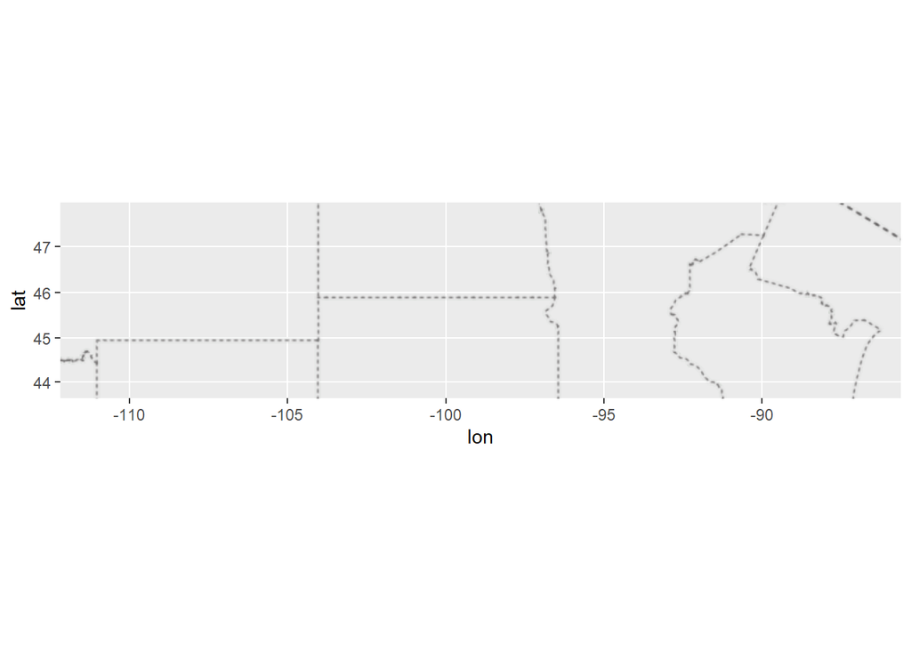

```r
ggmap(map2)
```

9. Build a final map that overlays the recorded observations of wolves in the lower 48 states.

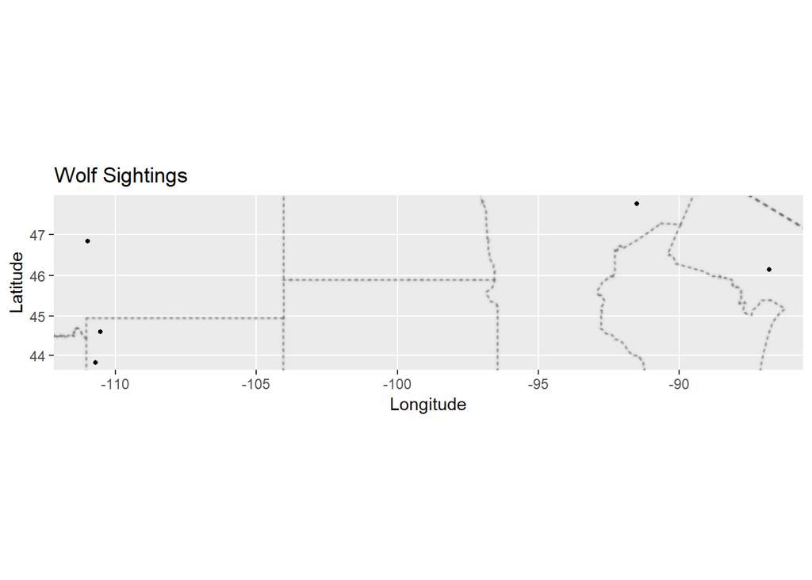

```r
ggmap(map2) + geom_point(data = wolves, aes(long, lat), size = 1) + labs(title = "Wolf Sightings", x = "Longitude", y = "Latitude")
```

10. Use the map from #9 above, but add some aesthetics. Try to `fill` and `color` by population.

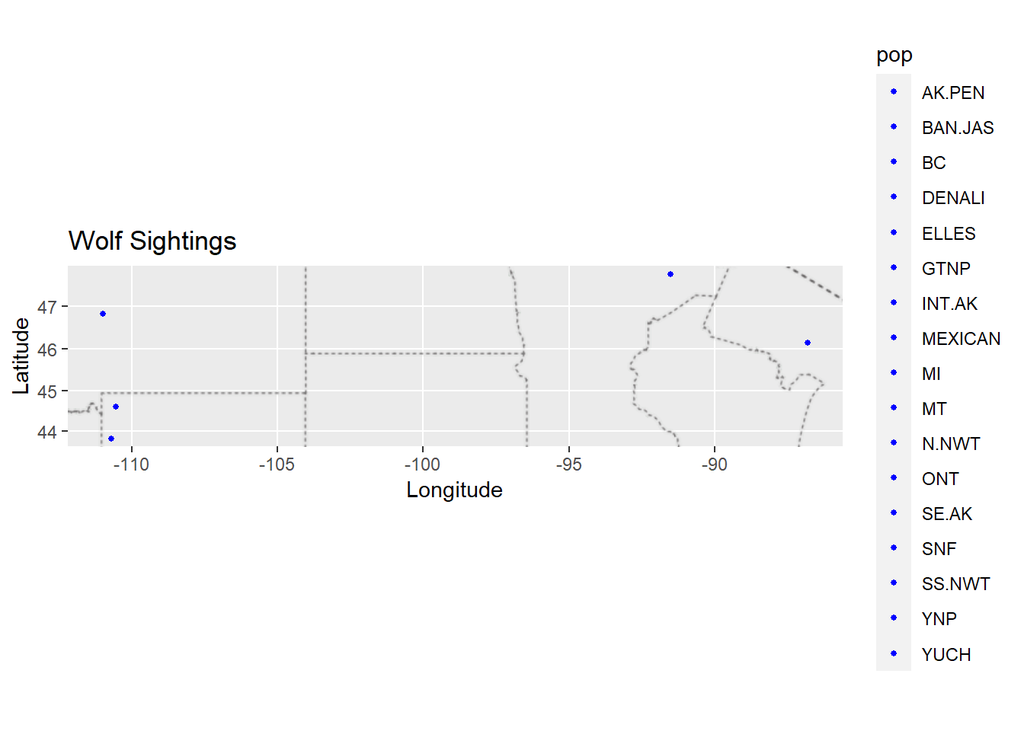

```r
ggmap(map2) + geom_point(data = wolves, aes(long, lat, fill = pop), size = 1, color = "blue") + labs(title = "Wolf Sightings", x = "Longitude", y = "Latitude")
```

## Push your final code to GitHub!

Please be sure that you check the `keep md` file in the knit preferences.